# Homework 10

Solutions for Questions 1 and 2 will be available after Monday, November 2, 2026. No solution will be provided for Question 3.

Use the RLT package for Questions 1 and 2: `RLT` in R or `rlt` in Python. The node-size parameter is `nmin` in R and `min_samples_leaf` in Python; both stop splitting a node when it contains at most that many observations. The candidate-predictor parameter is `mtry` in both languages. Use ordinary random forests, with reinforcement turned off.

## Question 1: Bias-variance trade-off simulation

Two important tuning parameters of random forests are node size and `mtry`. We have performed some preliminary analysis in class. The goal of this question is to perform a larger simulation study for these two tuning parameters.

Consider a regression model with five jointly normally distributed predictors. Each predictor has mean 0 and variance 1, and the correlation between any two different predictors is 0.3. The response is

$$Y=X_1+X_3+X_5+\varepsilon,
\qquad \varepsilon\sim N(0,1),$$

where the noise is independent of the predictors. Thus the true regression function is $f(\mathbf{x})=x_1+x_3+x_5$.

1. Set up a simulation study with 100 repetitions. Generate 200 test predictor vectors once and keep them fixed. In each repetition, generate 200 new training observations and use the same training data for all tuning settings. Fit 500-tree forests, drawing 200 observations with replacement for each tree. Make the following two comparisons:
   - Fix `mtry` at 3 and vary node size over $1,5,10,20,30$.
   - Fix node size at 10 and vary `mtry` over $1,2,3,4,5$.

   Leave all other fitting parameters at their defaults. Record the predictions at each test point across repetitions. For each setting, estimate the squared bias and variance at each test point, then average them over the 200 test points. Compare predictions with $f(\mathbf{x})$ when estimating bias. Produce two figures, one for each tuning parameter, showing the averaged squared bias and variance. Set a random seed and report it.

```r
library(RLT)
library(MASS)

# Reproducibility
set.seed(123)

n_train <- 200
n_test <- 200
n_rep <- 100
p <- 5

# Covariance matrix: variance = 1, correlation = 0.3
Sigma <- matrix(0.3, nrow = p, ncol = p)
diag(Sigma) <- 1

# Generate test predictors ONCE
X_test <- mvrnorm(
  n = n_test,
  mu = rep(0, p),
  Sigma = Sigma
)

# True regression function
f_test <- X_test[, 1] + X_test[, 3] + X_test[, 5]

# Two tuning experiments
settings <- unique(rbind(
  data.frame(nmin = c(1, 5, 10, 20, 30), mtry = 3),
  data.frame(nmin = 10, mtry = 1:5)
))

# Store predictions:
# test point x repetition x tuning setting
predictions <- array(
  NA_real_,
  dim = c(n_test, n_rep, nrow(settings))
)

# Monte Carlo simulation
for (r in seq_len(n_rep)) {

  # Generate new training data
  X_train <- mvrnorm(
    n = n_train,
    mu = rep(0, p),
    Sigma = Sigma
  )

  y_train <- X_train[, 1] +
    X_train[, 3] +
    X_train[, 5] +
    rnorm(n_train, mean = 0, sd = 1)

  # Apply all settings to the same training data
  for (k in seq_len(nrow(settings))) {

    fit <- RLT::RLT(
      X_train, y_train,
      model = "regression",
      ntrees = 500,
      nmin = settings$nmin[k],
      mtry = settings$mtry[k],
      resample.prob = 1,
      resample.replace = TRUE,
      reinforcement = FALSE,
      ncores = 1,
      seed = 10000 + r
    )

    predictions[, r, k] <-
      as.numeric(predict(fit, X_test)$Prediction)
  }
}

# Calculate averaged squared bias and variance
results <- settings
results$Squared_Bias <- NA_real_
results$Variance <- NA_real_

for (k in seq_len(nrow(settings))) {

  P <- matrix(
    predictions[, , k],
    nrow = n_test,
    ncol = n_rep
  )

  # Mean prediction over repetitions
  mean_pred <- rowMeans(P)

  # Squared bias at each test point
  bias2 <- (mean_pred - f_test)^2

  # Variance at each test point
  variance <- apply(P, 1, var)

  # Average over 200 test points
  results$Squared_Bias[k] <- mean(bias2)
  results$Variance[k] <- mean(variance)
}

# Separate the two comparisons
node_results <- subset(results, mtry == 3)
mtry_results <- subset(results, nmin == 10)

node_results <- node_results[
  order(node_results$nmin),
]

mtry_results <- mtry_results[
  order(mtry_results$mtry),
]

knitr::kable(node_results, digits = 4)
```

| nmin | mtry | Squared_Bias | Variance |
| --- | --- | --- | --- |
| 1 | 3 | 0.1838 | 0.1998 |
| 5 | 3 | 0.1864 | 0.1938 |
| 10 | 3 | 0.1989 | 0.1818 |
| 20 | 3 | 0.2486 | 0.1664 |
| 30 | 3 | 0.3187 | 0.1615 |

```r
knitr::kable(mtry_results, digits = 4)
```

|  | nmin | mtry | Squared_Bias | Variance |
| --- | --- | --- | --- | --- |
| 6 | 10 | 1 | 0.5026 | 0.1151 |
| 7 | 10 | 2 | 0.2600 | 0.1471 |
| 3 | 10 | 3 | 0.1989 | 0.1818 |
| 9 | 10 | 4 | 0.1824 | 0.2090 |
| 10 | 10 | 5 | 0.1745 | 0.2299 |

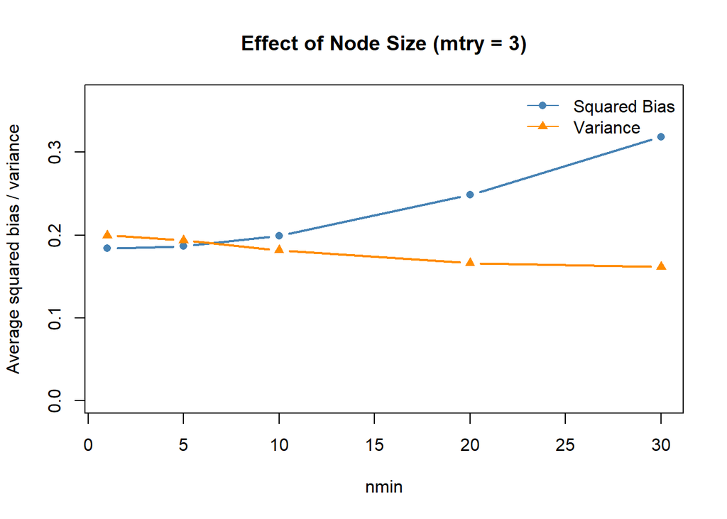

```r
Sigma <- matrix(0.3, 5, 5)
diag(Sigma) <- 1

resample.prob = 1
resample.replace = TRUE

mean_pred <- rowMeans(P)
bias2 <- (mean_pred - f_test)^2
variance <- apply(P, 1, var)

plot_tradeoff <- function(dat, xvar, title) {

  x <- dat[[xvar]]

  plot(
    x, dat$Squared_Bias,
    type = "b",
    pch = 16,
    col = "steelblue",
    lwd = 2,
    ylim = c(0, max(dat$Squared_Bias, dat$Variance) * 1.15),
    xlab = xvar,
    ylab = "Average squared bias / variance",
    main = title
  )

  lines(
    x, dat$Variance,
    type = "b",
    pch = 17,
    col = "darkorange",
    lwd = 2
  )

  legend(
    "topright",
    legend = c("Squared Bias", "Variance"),
    col = c("steelblue", "darkorange"),
    pch = c(16, 17),
    lty = 1,
    bty = "n"
  )
}

# Figure 1
plot_tradeoff(
  node_results,
  "nmin",
  "Effect of Node Size (mtry = 3)"
)
```

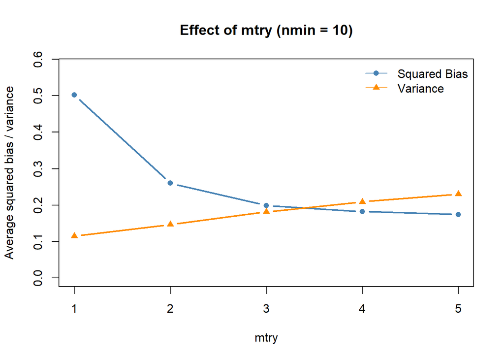

```r
# Figure 2
plot_tradeoff(
  mtry_results,
  "mtry",
  "Effect of mtry (nmin = 10)"
)
```

I conducted a Monte Carlo simulation with 100 repetitions to examine how node size and `mtry` affect the bias and variance of random forests. Five correlated predictors were generated from a multivariate normal distribution with zero means, unit variances, and pairwise correlations of 0.3. The response was generated as $Y=X_1+X_3+X_5+\varepsilon$, where $\varepsilon\sim N(0,1)$.

I generated 200 test predictor vectors once and kept them fixed across repetitions. In each repetition, I generated 200 new training observations and fitted 500-tree random forests under the specified tuning settings, using bootstrap samples of size 200. For each test point, I calculated the squared difference between the mean prediction across repetitions and the true regression function to estimate squared bias. I also calculated the sample variance of predictions across repetitions. These quantities were then averaged over the 200 test points. The random seed for data generation was set to 123.

2. Discuss your results in terms of the bias-variance trade-off:
   - How does a large node size, such as 30, affect the fit in this example?
   - What are the benefits and drawbacks of using a large `mtry` value?
   - If each tree instead sampled 100 observations with replacement, would you expect the preferred node size to shift toward smaller or larger values? Explain your reasoning. You may use an additional simulation to help, but a particular pattern is not guaranteed.

The simulation results illustrate the bias–variance trade-off of random forests. As node size increased from 1 to 30, squared bias increased from 0.1838 to 0.3187, while variance decreased from 0.1998 to 0.1615. This suggests that a large node size restricts tree growth and leads to underfitting. In this simulation, node sizes of 5 and 10 produced the lowest combined squared bias and variance.

For mtry, increasing its value from 1 to 5 reduced squared bias from 0.5026 to 0.1745, but increased variance from 0.1151 to 0.2299. A larger mtry increases the chance of selecting informative predictors at each split, reducing bias. However, it also makes trees more similar, potentially increasing variance. In this simulation, mtry = 3 achieved the lowest combined squared bias and variance.

If each tree used a bootstrap sample of 100 rather than 200 observations, I would expect the preferred node size to potentially shift toward smaller values. With fewer observations in each tree, a large node size could cause splitting to stop too early and increase bias. A smaller node size may help retain sufficient model flexibility. However, smaller bootstrap samples can also increase prediction instability, so the optimal node size depends on the balance between bias and variance and is not guaranteed to shift in a particular direction.

## Question 2: Tuning random forests for MNIST

Use `mnist-first2000.csv.gz` from the combined ZIP. It contains 2,000 MNIST observations, with the digit label `Digit` and 784 pixel values.

- From the first 1,000 observations, keep digits 1, 6, and 7 as the training data. From the remaining 1,000 observations, keep the same digits as the test data.
- Fit PCA to the training pixels, centering but not scaling them. Use the first 20 principal components as predictors, and project the test observations using the same training means and loadings.

Complete the following tasks using RLT classification forests with 1,000 trees. For each tree, draw a bootstrap sample of the same size as the training set.

1. Fit a random forest with the default `mtry` and node-size settings. Report the out-of-bag (OOB) misclassification rate.

```r
library(RLT)

set.seed(123)

# Locate the MNIST file
files <- list.files(
  path = ".",
  pattern = "^mnist-first2000\\.csv\\.gz$",
  recursive = TRUE,
  full.names = TRUE
)

stopifnot(length(files) >= 1)

mnist <- read.csv(files[1], check.names = FALSE)

# Check data structure
stopifnot(
  nrow(mnist) == 2000,
  "Digit" %in% names(mnist)
)

pixel_cols <- setdiff(names(mnist), "Digit")
stopifnot(length(pixel_cols) == 784)

# Preserve the original observation order
train_idx <- (1:1000)[
  mnist$Digit[1:1000] %in% c(1, 6, 7)
]

test_idx <- (1001:2000)[
  mnist$Digit[1001:2000] %in% c(1, 6, 7)
]

# Training and test predictors
X_train <- as.matrix(mnist[train_idx, pixel_cols])
X_test <- as.matrix(mnist[test_idx, pixel_cols])

# Training labels
y_train <- factor(
  mnist$Digit[train_idx],
  levels = c(1, 6, 7)
)

# Fit PCA using training data ONLY
pca <- prcomp(
  X_train,
  center = TRUE,
  scale. = FALSE
)

# Retain first 20 principal components
PC_train <- pca$x[, 1:20, drop = FALSE]

# Project test data using training PCA
PC_test <- predict(
  pca,
  newdata = X_test
)[, 1:20, drop = FALSE]

# Check dimensions
dim(PC_train)
```

```
[1] 327  20
```

```r
dim(PC_test)
```

```
[1] 317  20
```

```r
# Proportion of variance explained by first 20 PCs
explained <- sum(pca$sdev[1:20]^2) /
  sum(pca$sdev^2)

cat("Variance explained by 20 PCs:",
    round(explained, 4), "\n")
```

```
Variance explained by 20 PCs: 0.7713
```

```r
# Default random forest
fit_default <- RLT::RLT(
  PC_train,
  y_train,
  model = "classification",
  ntrees = 1000,
  resample.prob = 1,
  resample.replace = TRUE,
  reinforcement = FALSE,
  ncores = 1,
  seed = 123
)

# OOB misclassification rate
oob_default <- mean(
  fit_default$Prediction != y_train
)

cat(
  "Default OOB misclassification rate:",
  round(oob_default, 4), "\n"
)
```

```
Default OOB misclassification rate: 0.0428
```

```r
print(fit_default)
```

```
--------------------------------------
RLT Classification Forest
--------------------------------------
              (N, P) = (327, 20)
          # of trees = 1000
        (mtry, nmin) = (10, 5)
      split generate = Best
            sampling = 100% w/ replace
          importance = none
      OOB misclass = 4.28%
--------------------------------------
```

I fitted a classification random forest using the first 20 principal components, with 1,000 trees and the default mtry and node-size settings. Each tree was trained using a bootstrap sample equal in size to the training set. I evaluated the model using the out-of-bag (OOB) misclassification rate, which is calculated from predictions made by trees that did not include the corresponding observations in their bootstrap samples.

The default forest produced an OOB misclassification rate of 4.28%.

2. Construct a grid of `mtry` and node-size values to tune the model. Select the setting using OOB misclassification rate. Report the OOB error for each setting and the selected values. Calculate and present the selected forest’s OOB permutation variable importance for the 20 principal components. Comment on your results.

```r
# Define tuning grid
tuning_grid <- expand.grid(
  mtry = c(2, 5, 10, 15, 20),
  nmin = c(1, 5, 10, 20)
)

tuning_grid$OOB_Error <- NA_real_

# Fit all tuning combinations
for (k in seq_len(nrow(tuning_grid))) {

  fit <- RLT::RLT(
    PC_train,
    y_train,
    model = "classification",
    ntrees = 1000,
    mtry = tuning_grid$mtry[k],
    nmin = tuning_grid$nmin[k],
    resample.prob = 1,
    resample.replace = TRUE,
    reinforcement = FALSE,
    ncores = 1,
    seed = 123
  )

  tuning_grid$OOB_Error[k] <- mean(
    fit$Prediction != y_train
  )
}

# Report all results
knitr::kable(
  tuning_grid,
  digits = 4,
  caption = "OOB misclassification rates for tuning settings"
)
```

OOB misclassification rates for tuning settings

| mtry | nmin | OOB_Error |
| --- | --- | --- |
| 2 | 1 | 0.0336 |
| 5 | 1 | 0.0367 |
| 10 | 1 | 0.0398 |
| 15 | 1 | 0.0459 |
| 20 | 1 | 0.0489 |
| 2 | 5 | 0.0306 |
| 5 | 5 | 0.0367 |
| 10 | 5 | 0.0428 |
| 15 | 5 | 0.0489 |
| 20 | 5 | 0.0489 |
| 2 | 10 | 0.0336 |
| 5 | 10 | 0.0367 |
| 10 | 10 | 0.0428 |
| 15 | 10 | 0.0489 |
| 20 | 10 | 0.0489 |
| 2 | 20 | 0.0367 |
| 5 | 20 | 0.0367 |
| 10 | 20 | 0.0459 |
| 15 | 20 | 0.0489 |
| 20 | 20 | 0.0520 |

```r
# Select best setting
best_idx <- which.min(tuning_grid$OOB_Error)

best_mtry <- tuning_grid$mtry[best_idx]
best_nmin <- tuning_grid$nmin[best_idx]
best_oob <- tuning_grid$OOB_Error[best_idx]

cat("Selected mtry:", best_mtry, "\n")
```

```
Selected mtry: 2
```

```r
cat("Selected nmin:", best_nmin, "\n")
```

```
Selected nmin: 5
```

```r
cat("Minimum OOB error:", best_oob, "\n")
```

```
Minimum OOB error: 0.03058104
```

```r
# Fit selected forest with permutation importance
best_fit <- RLT::RLT(
  PC_train,
  y_train,
  model = "classification",
  ntrees = 1000,
  mtry = best_mtry,
  nmin = best_nmin,
  resample.prob = 1,
  resample.replace = TRUE,
  reinforcement = FALSE,
  importance = "permute",
  ncores = 1,
  seed = 123
)

# Extract variable importance
VI_table <- data.frame(
  PC = paste0("PC", 1:20),
  Importance = as.numeric(best_fit$VarImp)
)

# Rank components from highest to lowest importance
VI_table <- VI_table[
  order(VI_table$Importance, decreasing = TRUE),
]

knitr::kable(
  VI_table,
  digits = 4,
  caption = "OOB permutation importance of principal components"
)
```

OOB permutation importance of principal components

|  | PC | Importance |
| --- | --- | --- |
| 2 | PC2 | 0.2080 |
| 1 | PC1 | 0.1350 |
| 3 | PC3 | 0.0399 |
| 5 | PC5 | 0.0350 |
| 6 | PC6 | 0.0342 |
| 11 | PC11 | 0.0226 |
| 7 | PC7 | 0.0203 |
| 18 | PC18 | 0.0190 |
| 14 | PC14 | 0.0145 |
| 20 | PC20 | 0.0135 |
| 16 | PC16 | 0.0131 |
| 4 | PC4 | 0.0129 |
| 12 | PC12 | 0.0122 |
| 10 | PC10 | 0.0118 |
| 19 | PC19 | 0.0110 |
| 8 | PC8 | 0.0092 |
| 13 | PC13 | 0.0089 |
| 17 | PC17 | 0.0073 |
| 15 | PC15 | 0.0068 |
| 9 | PC9 | 0.0064 |

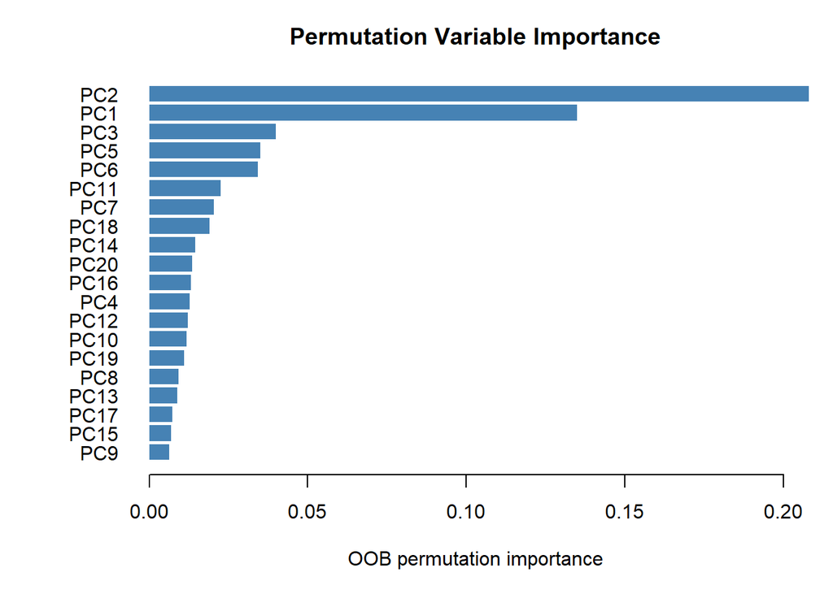

```r
# Variable importance plot
par(mar = c(5, 6, 3, 1))

barplot(
  rev(VI_table$Importance),
  names.arg = rev(VI_table$PC),
  horiz = TRUE,
  las = 1,
  col = "steelblue",
  border = NA,
  main = "Permutation Variable Importance",
  xlab = "OOB permutation importance"
)
```

I constructed a grid of five mtry values (2, 5, 10, 15, and 20) and four node-size values (1, 5, 10, and 20), resulting in 20 candidate settings. For each combination, I fitted a classification random forest with 1,000 trees and calculated its OOB misclassification rate. I selected the combination with the lowest OOB error without using the test data.

The selected values were mtry = 2 and nmin = 5, with an OOB misclassification rate of 3.06%.

I then calculated OOB permutation variable importance for the selected forest. The importance values indicate how much prediction performance deteriorates when each principal component is randomly permuted among OOB observations. Components with larger positive importance values contribute more to the model’s predictive performance. However, variable importance is not necessarily related to the proportion of predictor variance explained by each principal component, because PCA is unsupervised whereas the random forest is trained to distinguish the digit classes.

3. Apply the selected model to the test data and report the misclassification rate and confusion matrix. Use the test labels only for this final assessment.

```r
# Use test labels only for final assessment
y_test <- factor(
  mnist$Digit[test_idx],
  levels = c(1, 6, 7)
)

# Predict on test PCA scores
test_pred <- predict(
  best_fit,
  PC_test
)$Prediction

# Test misclassification rate
test_error <- mean(test_pred != y_test)

cat(
  "Test misclassification rate:",
  round(test_error, 4), "\n"
)
```

```
Test misclassification rate: 0.0189
```

```r
cat(
  "Test accuracy:",
  round(1 - test_error, 4), "\n"
)
```

```
Test accuracy: 0.9811
```

```r
# Confusion matrix
confusion_matrix <- table(
  Actual = y_test,
  Predicted = factor(
    test_pred,
    levels = levels(y_train)
  )
)

confusion_matrix
```

```
      Predicted
Actual   1   6   7
     1 101   0   3
     6   0 106   0
     7   0   3 104
```

```r
knitr::kable(
  confusion_matrix,
  caption = "Confusion matrix on the test set"
)
```

Confusion matrix on the test set

|  | 1 | 6 | 7 |
| --- | --- | --- | --- |
| 1 | 101 | 0 | 3 |
| 6 | 0 | 106 | 0 |
| 7 | 0 | 3 | 104 |

I applied the selected random forest to the held-out test data using the principal component scores obtained from the training PCA transformation. The test labels were used only for this final evaluation.

The test misclassification rate was 1.89%, corresponding to a classification accuracy of 98.11% The confusion matrix summarizes the predicted and actual digit classes, with correct classifications appearing on the diagonal and misclassifications appearing in the off-diagonal cells.

The comparison between the OOB and test errors provides an assessment of how well the selected model generalizes to unseen observations. The test set was not used during hyperparameter selection.

## Question 3: Planning a random-forest analysis skill

In earlier homework, some students wrote long skill files with detailed instructions, while others wrote short skills emphasizing their specific requirements or references. These approaches may perform differently depending on the AI and the task. A capable AI may already know standard ways to perform an analysis, so some instructions may be redundant, add little value, or sometimes make the analysis worse. It may be more useful to specify your personal choices for the analysis. An AI with more limited knowledge may benefit from detailed instructions that remind it of the steps to perform.

1. Write one paragraph describing how you would write a skill that directs an AI to perform a random-forest analysis and produce a report for a future dataset. Discuss how you would balance standard analysis instructions with your personal preferences, considering the AI’s capabilities.

For me, I would write a concise and dataset-independent skill that focuses on the essential steps of a random-forest analysis while emphasizing my specific requirements and preferences. For a capable AI, detailed instructions about standard procedures may be unnecessary because it already knows how to prepare data, fit models, and evaluate prediction performance. Excessive instructions could also reduce flexibility when dealing with different datasets. However, I would explicitly specify important requirements, such as reproducibility, preventing data leakage, and selecting tuning parameters using appropriate methods. For an AI with more limited capabilities, I would provide a clearer workflow and references to relevant documentation. I would also include my preferences for tables, figures, interpretations, and report organization to ensure that the final output is both statistically appropriate and easy to understand.

2. Provide **10 instructions** you would consider including in the skill, **ordered from the most basic instructions to the more personal preferences**. Your list may cover computation, tuning, tables, figures, interpretation, presentation, or other aspects of a random-forest report.

You only need to discuss how the skill should be written. You are not required to write a complete skill file or test it.

1.Identify the analysis objective. Determine the response variable, predictor variables, and whether the task is regression or classification.

2.Inspect and prepare the data. Examine variable types, missing values, and potential data quality issues before fitting any models.

3.Separate training and test data appropriately. Prevent data leakage and ensure that the test set is reserved for final model evaluation.

4.Apply necessary preprocessing. Perform transformations or dimensionality reduction when appropriate, estimating preprocessing parameters using training data only.

5.Fit a reproducible random forest. Use R and the RLT package, set random seeds, and document the main fitting parameters.

6.Tune model parameters systematically. Compare reasonable values of mtry and node size using OOB prediction error, and select the best-performing setting without using test data.

7.Evaluate predictive performance. Report appropriate performance metrics on the independent test set, such as misclassification rate and confusion matrix for classification or MSE for regression.

8.Assess variable importance. Calculate permutation variable importance and interpret the contributions of important predictors while acknowledging the limitations of this measure.

9.Present results clearly. Organize tuning results and variable importance in well-formatted tables and figures with informative labels, titles, and captions.

10.Follow my reporting preferences. Produce a concise and well-organized Quarto report with reproducible R code, clear explanations of the main findings, and a discussion of model limitations. Avoid unnecessary technical details or repetitive explanations.